# Real-time analysis of the COVID-19 pandemic in Poland

### **Rafał J. Mostowy**

#### Malopolska Centre of Biotechnology, Jagiellonian University in Krakow, Poland

#### Last updated: 21/05/2020

#### Correspondence: rafal.mostowy@uj.edu.pl

## Introduction

The COVID-19 pandemic in Poland officially started on March 4th 2020 when the Polish authorities reported the first confirmed case of the disease. The first death was reported 8 days later, on March 12th, and the governmental lockdowns were introduced between March 12th and March 16th. To better understand the epidemiological dynamics of COVID-19 in Poland as well as the efficacy of governmental lockdowns, I applied an approach developed by my [colleagues at the University of Bern](https://ispmbern.github.io/covid-19/swiss-epidemic-model), which is based on the idea of fitting a [mathematical SEIR model](https://en.wikipedia.org/wiki/Compartmental_models_in_epidemiology#The_SEIR_model) to the number of reported deaths in COVID-19 patients, arguing that such cases are unlikely to be underreported. I fitted this model to the official numbers reported by the Polish Ministry of Health, collected and published by [Michał Rogalski](https://twitter.com/micalrg) under [this link](https://docs.google.com/spreadsheets/d/1ierEhD6gcq51HAm433knjnVwey4ZE5DCnu1bW7PRG3E/htmlview#gid=1400401584). The following analysis is an updated version of an earlier report, which has now been updated through changes to the mathematical model and the most recent data up to (and including from) 20/05/2020. The original report can be found in both [Polish](https://rmostowy.github.io/covid-19/prognoza-polska) and [English](https://rmostowy.github.io/covid-19/projections-poland). Details of the methodology can be found [here](https://rmostowy.github.io/covid-19/methodology). The code and data are accessible under [this link](https://github.com/rmostowy/rmostowy.github.io/tree/master/covid-19/code/v2).

## Results

Using the following approach, I estimate the following parameters of the COVID-19 pandemic in Poland. Before the introduction of the governmental lockdowns, the basic reproduction number, $R_0$, was 6.37 (95% confidence interval: 4.81 - 8.65), and the Polish epidemic was seeded on 26/02/2020 (95% CI: 20/02/2020 - 29/02/2020). Governmental lockdowns have reduced $R_0$ by 85% (95% CI: 80% - 89%, resulting in an effective reproduction number $R(t)$ of 0.948 (95% CI: 0.912 - 0.981). **Figure 1** shows the estimates of $R$ over time, suggesting that it has been decreasing in recent days. Using these estimates we can project the current epidemiological dynamics onto the future, asking what impact it would have on the Polish health care in the coming weeks and months (**Figure 2**). Please note however that such a projection assumes that the epidemiological parameters will not change with incoming data and varying seasons, which is very unlikely. Hence, **these projections should not and cannot be interpreted as a forecast of the COVID-19 pandemic in Poland**. Instead, they should be viewed as a potential impact of the epidemic on the health care assuming that the disease dynamics remain identical to those captured by the model on 21/05/2020.

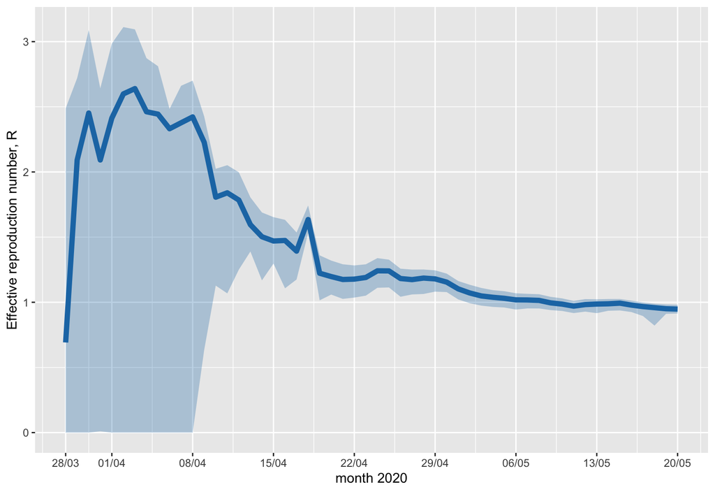

**Figure 1. Estimates of the effective reproduction number, $R$, over time.** Estimated value of the effective reproduction number, $R$, depending on the date of the last datapoint. The line shows the estimated value and the shaded area shows the 95% confidence interval.

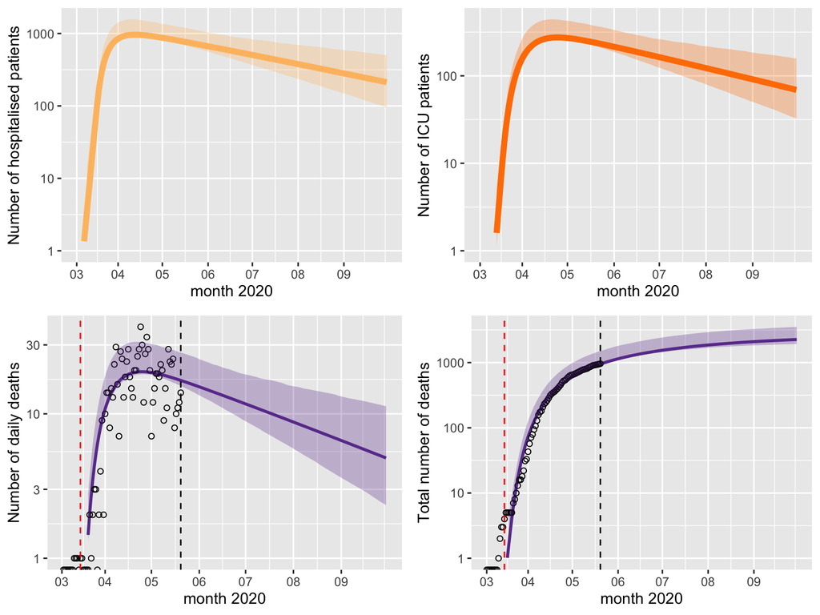

**Figure 2. Potential impact of the epidemic on the Polish health care.** Number of hospitalised patients (light orange), ICU patients (dark orange), daily number of deaths and cumulative number of deaths (purple) over time, assuming parameter values estimated on 21/05/2020. Shaded area reflects the 95% confidence interval. Dashed red line shows the date of introduction of governmental lockdowns (taken as 16/03) and the blacked dashed line shows the date of the last datapoint (20/05/2020).